# tasks

[figure not shown]

**Задача 1.**

**1.1 Описание задачи**

Все 64 процесса, находящихся на разных ЭВМ сети, одновременно выдали запрос на вход в критическую секцию. Реализовать программу, использующую широковещательный маркерный алгоритм для прохождения всеми процессами критических секций. Критическая секция:

```
<проверка наличия файла “critical.txt”>;
    if (<файл “critical.txt” существует>) {
        <сообщение об ошибке>;
        <завершение работы программы>;
    } else {
        <создание файла “critical.txt”>;
        Sleep (<случайное время>);
        <уничтожение файла “critical.txt”>;
    }
```

Для межпроцессорных взаимодействий использовать средства MPI. Получить временную оценку работы алгоритма. Оценить сколько времени потребуется для прохождения всеми критических секций, если маркером владеет нулевой процесс. Время старта равно 100, время передачи байта равно 1 (Ts=100,Tb=1). Процессорные операции, включая чтение из памяти и запись в память, считаются бесконечно быстрыми.

**1.2 Описание алгоритма.**

Широковещательный алгоритм (он же -- алгоритм Судзуки-Касами) для реализации прохождения всеми процессами критической секции.

Есть маркер -- некая структура, содержащая очередь запросов и массив $LN[1...N]$ номеров последних удовлетворенных запросов. У каждого процесса есть свой массив номеров запросов всех процессов: $RN_i$ для процесса с номером $i$.

Опишем основные этапы работы алгоритма.

- Вход в критическую секцию
  1. Если у процесса $i$ нет маркера, он увеличивает $RN_i[i]$ на единицу и посылает другим процессом сообщение "запрос" с номером процесса $i$ и номером запроса $Sn = RN_i[i]$.
  2. Если у процесса есть маркер, он выполняет критическую секцию.
- Прием "запроса".

  Если процесс $i$ получил сообщение с запросом от процесса $k$, он обновляет свой массив $RN_i$: устанваливает $RN_i[k] = max(RN_i[k], Sn)$. Если у $i$ есть свободный маркер, он посылает его $k$, но при условии, что запрос не устарел, то есть $RN_i[k] = LN[k] + 1$.
- Выход из критической секции. Пусть из критической секции выходит процесс $i$, значит маркер в данный момент находится у него.
  1. Установить $LN[i] = RN_i[i]$.
  2. Для каждого j, для которого: $RN_i[j] = LN[j] + 1$ и j нет в очереди запросов маркера, добавить его в конец очереди.
  3. Если после этого очередь маркера не пуста, удалить из нее первый элемент и переслать ему маркер.

**1.3 Временная оценка задачи**

Для оценки времени работы алгоритма нужно оценить число передач и время их выполнения. Время выполнения передачи = время старта + время на передачу данных. То есть на N байт нужно $T_N = T_s + N * T_b$. Для передачи запроса нужно передать $S_n$ и номер процесса, то есть $100 + 2 * 4 * 1 = 108$ единиц времени (е.в), так как передаются int-ы размером в 4 байта.

*В программной реализации номер процесса передается неявно, в status: status.MPI_Source.*

Оценим размер маркера: минимум по 64 int-а для LN и 64 для очереди (каждый процесс проходит КС 1 раз, больше в данной задаче не нужно). То есть на передачу маркера нужно $100 + 2 * 64 * 4 * 1 = 612$ е.в.

Начало работы.

Процесс 0 начал критическую секцию. Выполняет ее какое-то время. Остальные 63 процесса увеличивают номера своих запросов ($RN_i[i]$) на 1 и посылают широковещательные сообщения с этими новыми номерами(точнее инициируют отправку). То есть отправляют единицы, так как это самое начало работы.

Процесс 0 завершает критическую секцию. Теперь он должен принять сообщения, полученные от других процессов (запросы). Он может сделать это только по очереди(по крайней мере в случае с MPI и моей программой). Так что он 63 раза принимает сообщения с $Sn$ от разных процессов.

Затем он модифицирует маркер, меняет очередь запросов и пересылает маркер первому в очереди процессу. Не ограничивая общности можем сказать, что это будет процесс 1(хотя это в реальности это не совсем определено).

Прием маркера процессом 1 и оптравка его процессом 0 происходят одновременно. Время модификации маркера не учитывается.

Предположим, что процесс 0 проходит критическую секцию достаточно долго и за это время процессы 1-63 успели получить все запросы и обновить свои $RN$. Тогда когда первый процесс проходит критическую секцию, все запросы он уже получил. Ему нужно только модифицировать данные и переслать маркер. Следующему тоже. Последнему даже пересылать маркер не нужно.

В итоге имеем время на 63 пересылки маркера, время на 63 приема запросов процессом 0 и время прохождения критических секций. То есть $T_{work} = T_{cs_{sum}} + 63 * (T_{Sn} + T_m) = T_{cs_{sum}} + 63 * (108 + 612) = T_{cs_{sum}} + 45360$.

**1.4 Запуск кода.**

Для запуска первой программы нужно выполнить следубщие действия:

1. Перейти в папку с программой
2. Запустить скрипт командой "./start.sh" или ввести команды вручную:

   ```
   mpicc main.c -o task_1.out
   mpirun -np 4 task_1.out
   ```

Вместо 4 можно указать нужное число процессов. Код программы представлен в конце отчета.

**1.5 Пример работы программы.**

Здесь представлены результаты запуска на 3 процессах. На 4 и более вывода слишком много и он не помещается на экране

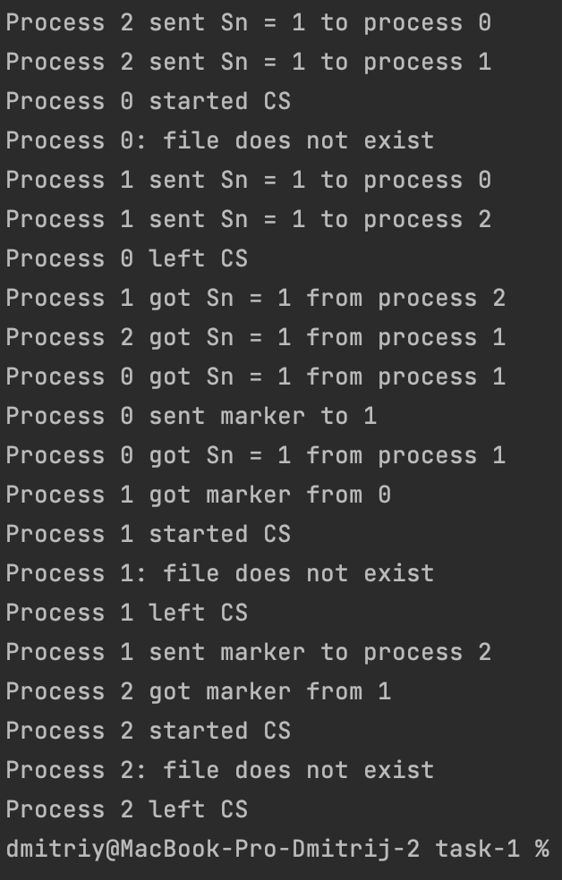

**1.6 Выводы**

Был реализован широковещательный маркерный алгоритм с использованием MPI. Была дана теоретическая оценка времени работы алгоритма для 64 процессов для случая, когда все процессы хотят одноврменно войти в критическую секцию, причем оценка легко адаптируема для любого числа процессов.

**Второе задание**

**2.1 Описание задания**

Доработать MPI-программу, реализованную в рамках курса “Суперкомпьютеры и параллельная обработка данных”:

Задание 89. Реализовать параллельное вычисление собственного интеграла методом Симпсона.

Добавить контрольные точки для продолжения работы программы в случае сбоя. Реализовать один из 3-х сценариев работы после сбоя:

- продолжить работу программы только на “исправных” процессах;
- вместо процессов, вышедших из строя, создать новые MPI-процессы, которые необходимо использовать для продолжения расчетов;
- при запуске программы на счет сразу запустить некоторое дополнительное количество MPI-процессов, которые использовать в случае сбоя.

Был выбран первый вариант: "продолжить работу программы только на “исправных” процессах".

**2.2 Детали реализации**

У программы есть начальное число процессов. Есть обработчик ошибок, который в случае ошибки в одном из процессов меняет число процессов. То есть переменная numprocs из 10 до ошибки станет равна 9.

В программе есть метка, обозначающая начало вычислений интеграла. Если ошибка происходит, то программа выполняется с этой метки, но уже с новым числом процессов. Каждому процессу в таком случае приходится вычислять больше данных, чем было изначально. Это может быть чуть понятнее по коду.

**2.3 Запуск программы**

1. Перейти в папку с программой
2. Выполнить команду `source dockervars.sh`
3. Выполнить команду `make`
4. Запустить программу: `mpirun -np 10 --with-ft ulfm ./task_2`

В качестве альтернативы можно использовать ./start.sh.

Вместо 10 можно указать нужное число процессов. Для запусков после первого необходимо запускать только последнюю команду. В данном примере начали с 10 процессов, но 1 сломался и вычисления были продолжены на 9. Код программы в конце отчета

**2.5 Пример работы программы**

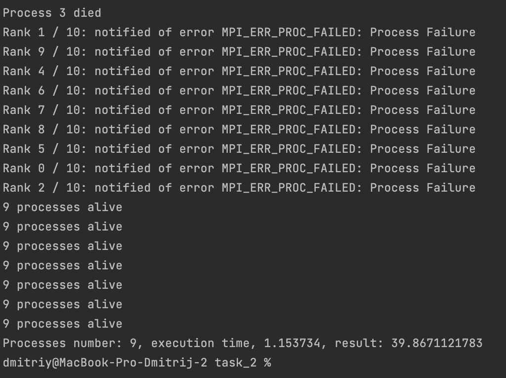

**2.6 Выводы**

Программа для вычисления интеграла методом Симпсона была модернизирована для большей устойчивости. Теперь в случае ошибки в каком-то из процессов (ошибки, при которой вычисления не были завершены) программа может продолжать работу, выполняя вычисления на меньшем числе процессов. Программа может работать и в ситуации, если сломано более одного процесса.

```python
Ссылка на репозиторий с исходными кодами программ и исследований.
https://github.com/stamplevskiyd/SKIPOD/tree/main/2022
```

[output not shown]

**Код первой программы**

```python
#include <stdio.h>
#include <stdlib.h>
#include <mpi.h>
#include <stdbool.h>
#include <unistd.h>

#define PROC_COUNT 64
#define QUEUE_LENGTH 128

#define SN_TAG 1
#define MARKER_TAG 2
#define EMPTY_CELL (-1)

void pass_cs(int proc_num){
    printf("Process %d started CS\n", proc_num);
    FILE *f;
    const char *filename = "critical.txt";
    f = fopen(filename, "rb+");
    if (!f){
        printf("Process %d: file does not exist\n", proc_num);
        f = fopen(filename, "w");
        sleep(2);
        remove(filename);
    }
    else{
        printf("Process %d: file exists, ERROR\n", proc_num);
        perror("File exists");
        exit(1);
    }
    printf("Process %d left CS\n", proc_num);
};

enum states {IDLE, REQUESTS, CS, WAITING};

struct Marker{
    int LN[PROC_COUNT];
    int queue[QUEUE_LENGTH];
};

int main(int argc, char** argv){
    int numtasks, rank, Sn, finished_all, finished_current, sender;
    const int root = 0;
    bool has_marker;
    MPI_Status status;
    MPI_Request request;
    enum states current_state = REQUESTS;
    int got_message;
    struct Marker marker;

    MPI_Init(&argc, &argv);
    MPI_Comm_size(MPI_COMM_WORLD, &numtasks);
    MPI_Comm_rank(MPI_COMM_WORLD, &rank);

    int RN[numtasks];

    /**
     * Сreating marker structure
     */
    int blocklengths[2] = {PROC_COUNT, QUEUE_LENGTH};
    MPI_Datatype Marker_Datatype;
    MPI_Datatype types[2] = {MPI_INT, MPI_INT};
    MPI_Aint offsets[2], address, start_address;
    MPI_Get_address(&marker, &start_address);
    offsets[0] = (MPI_Aint) 0;
    MPI_Get_address(&marker.queue, &address);
    offsets[1] = address - start_address;
    MPI_Type_create_struct(2, blocklengths, offsets, types, &Marker_Datatype);
    MPI_Type_commit(&Marker_Datatype);

    /**
     * Initialising arrays
     */
    for (int i = 0; i < numtasks; i++){
        RN[i] = 0;
    }

    for (int i = 0; i < PROC_COUNT; i++){
        marker.LN[i] = 0;
    }
    for (int i = 0; i < QUEUE_LENGTH; i++){
        marker.queue[i] = EMPTY_CELL;
    }

    has_marker = (rank == root) ? true : false;

    /**
     * Main work loop
     */
    while(true){
        fflush(stdout);
        /**
         * Getting Sn's
         */
        while(true && current_state != CS) {
            MPI_Iprobe(MPI_ANY_SOURCE, SN_TAG, MPI_COMM_WORLD, &got_message, &status);
            if (got_message) {
                sender = status.MPI_SOURCE;
                MPI_Recv(&Sn, 1, MPI_INT, MPI_ANY_SOURCE, SN_TAG, MPI_COMM_WORLD, &status);
                RN[sender] = (RN[sender] > Sn) ? RN[sender] : Sn;
                printf("Process %d got Sn = %d from process %d\n", rank, Sn, sender);
                if (has_marker && (RN[sender] == marker.LN[sender] + 1)) {
                    has_marker = false;
                    MPI_Send(&marker, 1, Marker_Datatype, sender, MARKER_TAG, MPI_COMM_WORLD);
                    printf("Process %d sent marker to %d\n", rank, sender);
                }
            }
            else
                break;
        }

        /**
         * Getting marker
         */
        MPI_Iprobe(MPI_ANY_SOURCE, MARKER_TAG, MPI_COMM_WORLD, &got_message, &status);
        if (got_message && current_state != CS){
            sender = status.MPI_SOURCE;
            MPI_Recv(&marker, 1, Marker_Datatype, MPI_ANY_SOURCE, MARKER_TAG, MPI_COMM_WORLD, &status);
            has_marker = true;
            printf("Process %d got marker from %d\n", rank, sender);
        }

        /**
         * Requesting to enter CS
         */
         if (current_state == REQUESTS){
             if (has_marker) {
                 current_state = CS;
                 pass_cs(rank);
             }
             else{
                 RN[rank]++;
                 Sn = RN[rank];
                 for (int i = 0; i < numtasks; i++) {
                     if (i != rank) {
                         MPI_Isend(&Sn, 1, MPI_INT, i, SN_TAG, MPI_COMM_WORLD, &request);
                         printf("Process %d sent Sn = %d to process %d\n", rank, Sn, i);
                     }
                 }
                 current_state = WAITING;
              }
         }

         /**
          * Request was sent, waiting for marker
          */
         else if (current_state == WAITING) {
             if (has_marker) {
                 current_state = CS;
                 pass_cs(rank);
             }
         }

        /**
         * Leaving CS
         */
        else if (current_state == CS){
            marker.LN[rank] = RN[rank];
            for (int i = 0; i < numtasks; i++){
                if (RN[i] == marker.LN[i] + 1){
                    int j = 0;
                    while (true){
                        if (marker.queue[j] == i)
                            break;
                        else if (marker.queue[j] != EMPTY_CELL)
                            j++;
                        else{
                            marker.queue[j] = i;
                            break;
                        }
                    }
                }
            }

            if (marker.queue[0] != EMPTY_CELL){
                int marker_receiver = marker.queue[0];
                for (int i = 0; i < QUEUE_LENGTH - 1; i++){
                    marker.queue[i] = marker.queue[i + 1];
                }
                marker.queue[QUEUE_LENGTH - 1] = EMPTY_CELL;
                has_marker = false;
                MPI_Send(&marker, 1, Marker_Datatype, marker_receiver, MARKER_TAG, MPI_COMM_WORLD);
                printf("Process %d sent marker to process %d\n", rank, marker_receiver);
            }
            current_state = IDLE;
        }

        /**
         * Checking if all processes finished CS
         */
        finished_current = (current_state == IDLE) ? 1 : 0;
        MPI_Allreduce(&finished_current, &finished_all, 1, MPI_INT, MPI_SUM,MPI_COMM_WORLD);
        if (finished_all == numtasks)
            break;
    }
    MPI_Barrier(MPI_COMM_WORLD);
    MPI_Finalize();
    return 0;
}
```

**Код второй программы**

```python
#include <stdio.h>
#include <stdlib.h>
#include <mpi.h>
#include <mpi-ext.h>
#include <signal.h>
#include <string.h>
#include <unistd.h>
#include <math.h>

#define KILLED_PROCESS 3
#define SEG_COUNT 262144

#define F(x) (cos(pow(x, 1.04) * atan(5.2 * exp(x + 2.3))) + log(fabs(pow(x, 4.3) + asin(-0.4)*pow(1.0013, 13.001))) + atan(acos(1/x) + 7)) / 100
#define A 2.0
#define B 200

int rank, numprocs;

double integral(double l, double r, int segnum) // вычисляет интеграл с заданным числом сегментов
{
    double res = 0, F_l, F_r, F_mid;
    double step_size = (r - l) / (double) segnum; // на каждом сегменте есть промежуточная точка в середине. эти точки за границы сегмента не считаем
    int i;
    double x_l = l, x_r = x_l + step_size, x_mid = x_l + (step_size) / 2.0;
    for (i = 0; i < segnum; i++)
    {
        F_l = F(x_l);
        F_r = F(x_r);
        F_mid = F(x_mid);
        res += F_r + 4.0 * F_mid + F_l;
        x_l += step_size;
        x_mid += step_size;
        x_r += step_size;
    }
    res *= step_size / 6.0; //возможно, увеличит точность, так как не будем каждый раз делить результат и складывать очень маленькие числа (риск переполнения очень мал)
    return res;
}

MPI_Comm main_comm;

static void err_handler(MPI_Comm *comm, int *err, ...) {
    int len;
    char errstr[MPI_MAX_ERROR_STRING];
    MPI_Comm_rank(main_comm, &rank);
    MPI_Comm_size(main_comm, &numprocs);
    MPI_Error_string(*err, errstr, &len);
    printf("Rank %d / %d: notified of error %s\n", rank, numprocs, errstr);

    // создаем новый коммуникатор
    MPIX_Comm_shrink(main_comm, &main_comm);
    // процесс узнает новое кол-во процессов и свой номер
    MPI_Comm_rank(main_comm, &rank);
    MPI_Comm_size(main_comm, &numprocs);
}

int main(int argc, char **argv)
{
    MPI_Init(&argc, &argv);
    MPI_Comm_rank(MPI_COMM_WORLD, &rank);
    MPI_Comm_size(MPI_COMM_WORLD, &numprocs);
    main_comm = MPI_COMM_WORLD;

    ///Устанавливаем обработчик ошибок
    MPI_Errhandler errh;
    MPI_Comm_create_errhandler(err_handler, &errh);
    MPI_Comm_set_errhandler(main_comm, errh);
    MPI_Barrier(main_comm);

    double l = A, r = B;
    double h;
    long int local_segnum;
    double local_res, local_r, local_l;
    double res;
    double timer;

    int ret_code;
    timer = MPI_Wtime();

    if (rank == KILLED_PROCESS) {
        printf("Process %d died\n", rank);
        raise(SIGKILL);
    }

    ///Начало вычислений
    start_count:

    h = (r - l) / numprocs;
    local_segnum = SEG_COUNT / numprocs; // пусть будет поровну у каждого процесса
    local_l = l + rank * h;
    local_r = local_l + h;
    local_res = integral(local_l, local_r, local_segnum);

    ///Проверяем, все ли до сюда дожили
    ret_code = MPI_Barrier(main_comm);
    if (ret_code != MPI_SUCCESS){
        printf("%d processes alive\n", numprocs);
        goto start_count;
    }

    ///До этого момента точно дожили все процессы, собираем данные и печатаем ответ
    MPI_Reduce(&local_res, &res, 1, MPI_DOUBLE, MPI_SUM, 0,main_comm); // складываем все результаты и передаем процессу 0
    timer = MPI_Wtime() - timer;
    if (rank == 0) {
        printf("Processes number: %d, execution time, %.6f, result: %.10f\n", numprocs, timer, res);
    }

    MPI_Finalize();
    return 0;
}
```